# Analysis for Renewable Energy: An Insight into Diffuse Flow and Temperature to Predict the Season

### Tanisha Kadia - Shiyu Jiang - Sohbat Sandhu - Valentina Ramirez

## Introduction

#### Provide some relevant background information on the topic so that someone unfamiliar with it will be prepared to understand the rest of your proposal

In a world that is becoming increasingly reliant on energy consumption, a critical need to find alternative renewable methods of energy is presented. A renewable form of energy is hydrothermal energy. Impacted by hydrothermal vents, and the Earth’s crust, hydrothermal energy can be a possible remedy for our energy and climate crisis. Diffuse flows are a discharge of low temperature fluids which impact the functioning of hydrothermal vents and consequently the amount of hydrothermal energy.

Morocco is one such nation who is facing a greater demand of energy and the locale of our dataset. Examining the amount of diffuse flows compared to temperature–two factors which influence hydrothermal energy–can provide insight into the trends influencing energy production. The purpose of this study is to determine in which season the hydrothermal energy production is most optimal and in which season energy capturing technology should be invested in based on diffuse flows and temperature. This study will help negate the dependency on fossil fuels and determine when the best investment will be to capture hydrothermal energy.

#### Clearly state the question you will try to answer with your project

Given the diffuse flows and the temperature in the Tetouan City in Morroco, what is the season?

#### Identify and describe the dataset that will be used to answer the question

The Power consumption of Tetouan city Data Set from the UCI Machine Learning Repository will be used to answer the research question. The large data set contains the predictors date, time, temperature, humidity, wind speed, general diffuse flows, diffuse flows, and power consumption of different zones in Tetouan city. Diffuse flows and temperature were selected because they impact Hydrothermal Energy.

## Data Analysis and Methods

```r
### We load this libaries because they provide us with the resources (ie. functions ) we need to do our analysis

#tidyverse make the code more readable by. setting each variable a column and each observation a row, each cell a single measurement
library(tidyverse)

#library(repr) is used to create readable viewable image representations of data
library(repr)

#library(rvest) helps us scrape data from web pages
library(rvest)

# tidymodel is a list of packages for modeling and statistical analysis that share the same structure with tidyverse.
library(tidymodels)

#stringr provides cohesive set of functions. Argument names and functions are consistent designed to be more efficiency in using strings
library(stringr)

options(repr.matrix.max.rows = 6)
source("tests.R")
source("cleanup.R")
```

[output not shown]

[output not shown]

```r
# We load the data using the funtion read_csv and we name it with a relevant information
Tetouan_city_power_consumption <-  read_csv ("https://archive.ics.uci.edu/ml/machine-learning-databases/00616/Tetuan%20City%20power%20consumption.csv")

Tetouan_city_power_consumption

# Now, we use the function make.names in order to make the column names syntatically valid for us!
colnames(Tetouan_city_power_consumption) <- make.names (colnames(Tetouan_city_power_consumption))
```

A spec_tbl_df: 52416 × 9

| DateTime <chr> | Temperature <dbl> | Humidity <dbl> | Wind Speed <dbl> | general diffuse flows <dbl> | diffuse flows <dbl> | Zone 1 Power Consumption <dbl> | Zone 2 Power Consumption <dbl> | Zone 3 Power Consumption <dbl> |
| --- | --- | --- | --- | --- | --- | --- | --- | --- |
| 1/1/2017 0:00 | 6.559 | 73.8 | 0.083 | 0.051 | 0.119 | 34055.70 | 16128.88 | 20240.96 |
| 1/1/2017 0:10 | 6.414 | 74.5 | 0.083 | 0.070 | 0.085 | 29814.68 | 19375.08 | 20131.08 |
| 1/1/2017 0:20 | 6.313 | 74.5 | 0.080 | 0.062 | 0.100 | 29128.10 | 19006.69 | 19668.43 |
| ⋮ | ⋮ | ⋮ | ⋮ | ⋮ | ⋮ | ⋮ | ⋮ | ⋮ |
| 12/30/2017 23:30 | 6.900 | 72.8 | 0.086 | 0.084 | 0.074 | 29590.87 | 25277.69 | 13806.48 |
| 12/30/2017 23:40 | 6.758 | 73.0 | 0.080 | 0.066 | 0.089 | 28958.17 | 24692.24 | 13512.61 |
| 12/30/2017 23:50 | 6.580 | 74.1 | 0.081 | 0.062 | 0.111 | 28349.81 | 24055.23 | 13345.50 |

```r
tidy_Tetouan_city_power_consumption <-Tetouan_city_power_consumption %>%

            # Step 1. We split up the DateTime column into date and time because each variable should have its own column
           separate(col = DateTime,
           into = c("date", "time"),
           sep = " ") %>%

           # Step 2. We find the average temperature and diffuse flow in each day of the year
            group_by(date) %>%
                            summarize(Temperature = mean(Temperature),
                                     diffuse.flows = mean(diffuse.flows)) %>%

           # Step 3. We  continue by splitting the date column into month/day/year because we just want to focus on month
           separate(col = date,
           into = c("month", "day", "year"),
           sep = "/") %>%

          # Step 4. We convert the month information from chr to num
             mutate (month = as.numeric (month)) %>%

            # Step 5. We classify each month in its respective season!
            mutate (Season =  case_when
                                            (month == 1  ~ "Winter",
                                             month <= 4  ~ "Spring",
                                             month <= 7  ~ "Summer",
                                             month <= 10  ~ "Fall",
                                             TRUE  ~ "Winter" )) %>%

            # Step 6. We select the variables we will focus on
            select (Season, Temperature, diffuse.flows)

tidy_Tetouan_city_power_consumption
```

A tibble: 364 × 3

| Season <chr> | Temperature <dbl> | diffuse.flows <dbl> |
| --- | --- | --- |
| Winter | 9.675299 | 25.99392 |
| Winter | 14.019583 | 47.99520 |
| Winter | 13.281736 | 55.91808 |
| ⋮ | ⋮ | ⋮ |
| Fall | 23.55521 | 61.37182 |
| Fall | 22.98757 | 40.67960 |
| Fall | 23.45326 | 30.06298 |

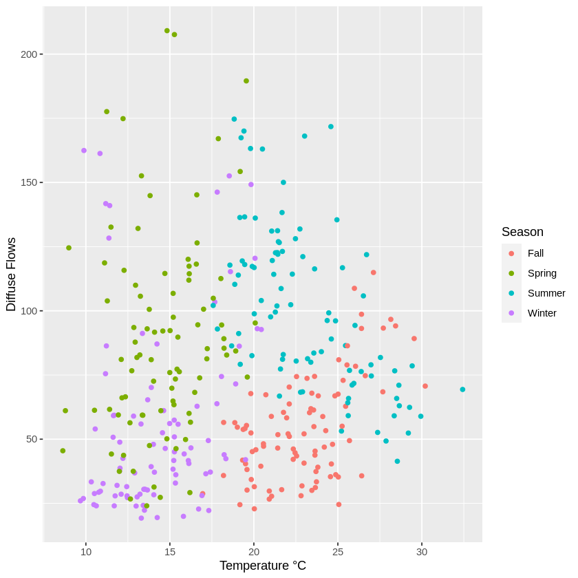

```r
# Step 7. We use ggplot to graph the relationship between temperature and diffuse flow and use each season as a class
plot1 <-   tidy_Tetouan_city_power_consumption %>%
                                    ggplot(aes(x = Temperature, y = diffuse.flows)) +
                                    geom_point(aes (colour = Season)) +
                                    labs(x = "Temperature °C", y = "Diffuse Flows", colour = "Season")

plot1
```

A tibble: 364 × 3

| Temperature <dbl> | diffuse.flows <dbl> | Season <fct> |
| --- | --- | --- |
| -1.7562119 | -1.2676081 | Winter |
| -0.9209941 | -0.6988407 | Winter |
| -1.0628502 | -0.4940220 | Winter |
| ⋮ | ⋮ | ⋮ |
| 0.9122933 | -0.3530342 | Fall |
| 0.8031610 | -0.8879603 | Fall |
| 0.8926938 | -1.1624167 | Fall |

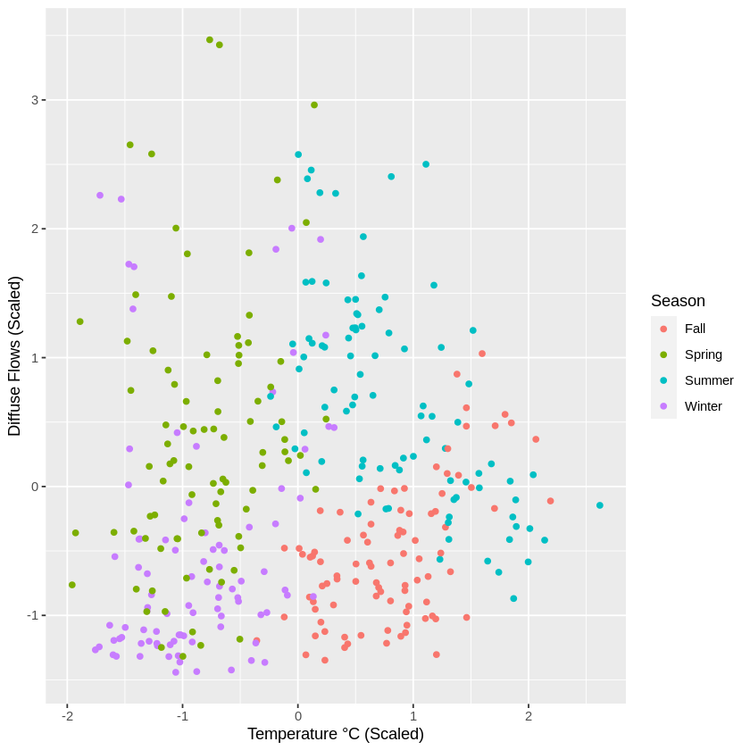

```r
# Step 8. We create a random seed
set.seed(9999)

# Step 9. We step scaled and step center our predictors (Temperature and Diffuse Flows). Remember we want to classify Season
tidy_Tetouan_city_power_consumption_recipe <- recipe(Season ~ Temperature + diffuse.flows, data =tidy_Tetouan_city_power_consumption) %>%
                step_scale(all_predictors()) %>%
                step_center(all_predictors())

# Step 10. We prep and bake
tidy_Tetouan_city_power_consumption_scaled <- tidy_Tetouan_city_power_consumption_recipe %>%
                                                prep() %>%
                                                bake(tidy_Tetouan_city_power_consumption)

tidy_Tetouan_city_power_consumption_scaled

# Step 11. We create a scatterplot with the variables now scaled!
tidy_Tetouan_city_power_consumption_scaled_graph <- tidy_Tetouan_city_power_consumption_scaled %>%
                                            ggplot(aes(x= Temperature, y= diffuse.flows)) +
                                            geom_point (aes (colour = Season)) +
                                            labs(x = "Temperature °C (Scaled)", y = "Diffuse Flows (Scaled)", colour = "Season")

tidy_Tetouan_city_power_consumption_scaled_graph
```

## Expected outcomes and significance:

#### What do you expect to find?

A prudent expectation would be to install hydrothermal energy capturing technology when the diffuse flows are the lowest and temperature is highest because that is when the hydrothermal energy production will be the most optimal. We expect to find Fall as the season in which diffuse flows are the lowest, temperature is the highest, and hence, hydrothermal energy production is most optimal.

#### What impact could such findings have?

The results proposed from this study will help Moroccan stakeholders invest into hydrothermal energy at the most optimal time and it will help the Moroccan people gain an alternate energy source. On a global scale, the efficient production and use of Hydrothermal Energy will decrease the dependency on non-renewable energy methods such as fossil fuels. The impact of these findings may lead us to be hopeful about a new energy era.

#### What future questions could this lead to?

How can the production of Hydrothermal Energy be increased? What other factors impact the release of Hydrothermal Energy? How do diffuse flows impact power consumption?